# HW10

7.18 (p. 424), Calculate  
(a) a C<sub>p</sub> plot corresponding to the possible regressions involving the Forbes data in Excersice 1.4  
(b) the AIC for each possible regression.  
Solution:  
(a)

```r
URL="http://users.stat.umn.edu/~guxxx192/courses/wichern_data/p1-4.dat"
forbes<-read.table(URL,col.names=c("sales","profits","assets"))
```

Cp plot

```r
library(leaps)
Cpplot <- function(cp, ...) {
  p <- max(cp$size)
  plot(cp$size, cp$Cp, xlab = "p", ylab = "Cp", type = "n")
  labels <- apply(
    cp$which, 1,
    function(x) {
      if (any(x) == FALSE) return("(0)")
      paste0("(", paste(as.character((1:(p - 1))[x]), collapse = ", "), ")")
    }
  )
  points(cp$size, cp$Cp, pch=16)
  text(cp$size, cp$Cp, labels, ...)
  abline(0, 1)
}
```

exhaustive search for all possible subset models

```r
exhaust <- leaps(forbes[, c(1,3)], forbes[, 2])
```

calculate Cp for the full model

```r
lm_fit <- lm(profits ~ sales + assets, data = forbes)
```

calculate Cp for the intercept model

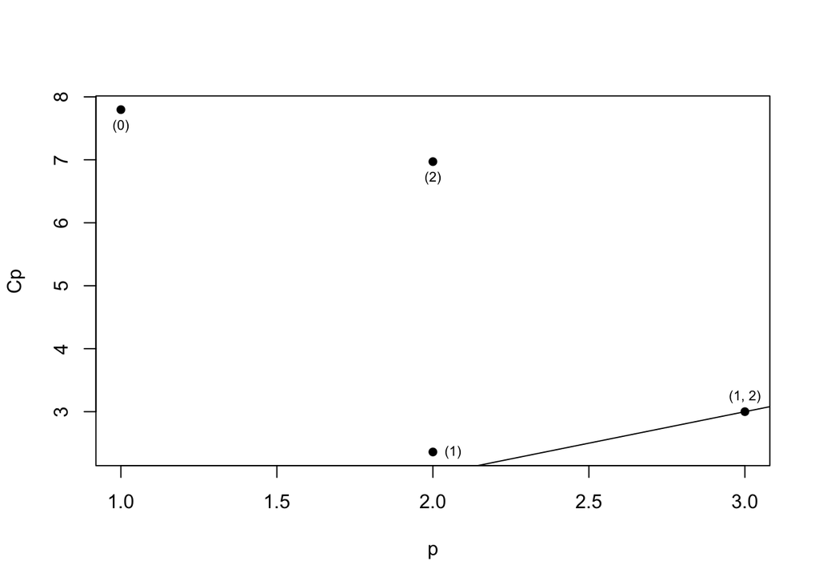

```r
fit0 = lm(profits ~ 1, data = forbes)
Cp0 = sum(fit0$residuals^2)/(summary(lm_fit)$sigma^2) -(nrow(forbes) - 2 * 1)
exhaust$which = rbind(rep(FALSE,2), exhaust$which)
rownames(exhaust$which)[1] = "0"
exhaust$size = c(1, exhaust$size)
exhaust$Cp = c(Cp0, exhaust$Cp)
Cpplot(exhaust, pos = c(1, 4, 1, 3), cex = 0.7)
```

(b)AIC

```r
AIC(lm_fit)
```

```
## [1] 59.83995
```

```r
AIC(lm(profits ~ sales, data = forbes))
```

```
## [1] 59.6155
```

```r
AIC(lm(profits ~ assets, data = forbes))
```

```
## [1] 64.00826
```

```r
AIC(fit0)
```

```
## [1] 63.97906
```

7.9 (p. 422),  
Consider the following data n one predictor variable z<sub>1</sub> and two responses Y<sub>1</sub> and Y<sub>2</sub>. Determinie the least squares estimate of the parameters in the bivariate straight-line regression model.  
Solution:

```r
z1 = c(-2,-1,0,1,2)
y1 = c(5,3,4,2,1)
y2 = c(-3,-1,-1,2,3)
ex79data = data.frame(y1=y1, y2=y2, z1=z1)
## fit multivariate linear model
fit = lm(cbind(y1, y2) ~ z1, data=ex79data)
fitted(fit) # fitted values
```

```
##    y1            y2
## 1 4.8 -3.000000e+00
## 2 3.9 -1.500000e+00
## 3 3.0  4.440892e-16
## 4 2.1  1.500000e+00
## 5 1.2  3.000000e+00
```

```r
fit$residuals # residuals
```

```
##     y1            y2
## 1  0.2 -5.097745e-16
## 2 -0.9  5.000000e-01
## 3  1.0 -1.000000e+00
## 4 -0.1  5.000000e-01
## 5 -0.2  1.755379e-16
```

```r
## verify decomposition
t(cbind(y1,y2)) %*% cbind(y1,y2)
```

```
##     y1  y2
## y1  55 -15
## y2 -15  24
```

```r
t(fitted(fit)) %*% fitted(fit) + t(fit$residuals) %*% fit$residuals
```

```
##     y1  y2
## y1  55 -15
## y2 -15  24
```

7.11 (p. 422),  
Let A be a positive definite matrix, so that d<sub>j</sub><sup>2</sup>(B) =(y<sub>j</sub>-B’z<sub>j</sub>)’A(y<sub>j</sub>-B’z<sub>j</sub>) is a squared statistical distance from the jth observation y<sub>j</sub> to its regression B’z<sub>j</sub>. Show that the choice $B=\hat{\beta}=(Z'Z)^{-1}Z'Y$ minimizes the sum of squared statistical distances, $Sum_{j=1}^{n}d_{j}^{2}(B)$, for any choice of positive definite A. Choices for A include $\Sigma^{-1}$ and I.  
Solution:  
Since A is positive definite, $RSS(B)=\sum_{j=1}^{n}d_{j}^{2}(B)=\sum_{j=1}^{n}(y_{j}-B'z_{j})'A(y_{j}-B'z_{j})=(Y-ZB)'A(Y-ZB)=tr((Y-ZB)'(Y-ZB)A)=Y'AY-2B'AZ'Y+B'AZ'ZB$.  
According to the porperty of trace , Because $\frac{\partial RSS(B)}{\partial B}= -2AZ'Y+2AZ'ZB=0$, then $AZ'ZB=AZ'Y$, so $\hat{\beta}=(AZ'Z)^{-1}AZ'Y=(Z'Z)^{-1}(Z'Y)$.  
A can be any choice if positive definite including $\Sigma^{-1}$ and $I$.  
7.25 (p. 426),  
(a)Perform a regression analysis using only the first response Y<sub>1</sub>.  
(i)Suggest and fit appropriate linear reression models (ii)Analyze the residuals.  
(iii)Constuct a 95% prediction interval for total TCAD for z<sub>1</sub>=1, z<sub>2</sub>=1200, z<sub>3</sub>=140, z<sub>4</sub>=70 and z<sub>5</sub>=85.  
(b)Repeat Part a using the second response Y<sub>2</sub>.  
(c)Perform a multivariate multiple regression analysis using both response Y<sub>1</sub> and Y<sub>2</sub>.  
(i)Suggest and fit appropriate linear reression models (ii)Analyze the residuals.  
(iii)Constuct a 95% prediction interval for total TCAD and Amount of amitriptyline for z<sub>1</sub>=1, z<sub>2</sub>=1200, z<sub>3</sub>=140, z<sub>4</sub>=70 and z<sub>5</sub>=85.Compare the ellipse with prediction intervals in Parts a and b. Comment.  
Solution:  
(a) (i)import the data and fatorize the z<sub>1</sub> as binary variable.

```r
ami = read.table("http://users.stat.umn.edu/~guxxx192/courses/wichern_data/t7-6.dat",
                 col.names=c(paste0("y", 1:2), paste0("z", 1:5)))
ami$z1 = as.factor(ami$z1) # geneder variable is a factor
```

I used ANOVA to select variable and found that only z<sub>2</sub> has significant effect.

```r
library(car)
y1aov=aov(y1 ~z1+z2+z3+z4+z5, data = ami)
summary(y1aov)
```

```
##             Df  Sum Sq Mean Sq F value   Pr(>F)
## z1           1  288658  288658   3.650   0.0825 .
## z2           1 5616926 5616926  71.018 3.97e-06 ***
## z3           1  341134  341134   4.313   0.0620 .
## z4           1  280973  280973   3.553   0.0861 .
## z5           1  308241  308241   3.897   0.0740 .
## Residuals   11  870008   79092
## ---
## Signif. codes:  0 '***' 0.001 '**' 0.01 '*' 0.05 '.' 0.1 ' ' 1
```

(ii)Look at the Residuals

```r
y1fit=lm(y1~z2,data=ami)
summary(y1fit)
```

```
##
## Call:
## lm(formula = y1 ~ z2, data = ami)
##
## Residuals:
##      Min       1Q   Median       3Q      Max
## -1061.05  -139.23    51.19   203.25   627.51
##
## Coefficients:
##             Estimate Std. Error t value Pr(>|t|)
## (Intercept) 462.8928   160.9090   2.877   0.0115 *
## z2            0.3065     0.0578   5.303 8.86e-05 ***
## ---
## Signif. codes:  0 '***' 0.001 '**' 0.01 '*' 0.05 '.' 0.1 ' ' 1
##
## Residual standard error: 422.8 on 15 degrees of freedom
## Multiple R-squared:  0.6521, Adjusted R-squared:  0.6289
## F-statistic: 28.12 on 1 and 15 DF,  p-value: 8.861e-05
```

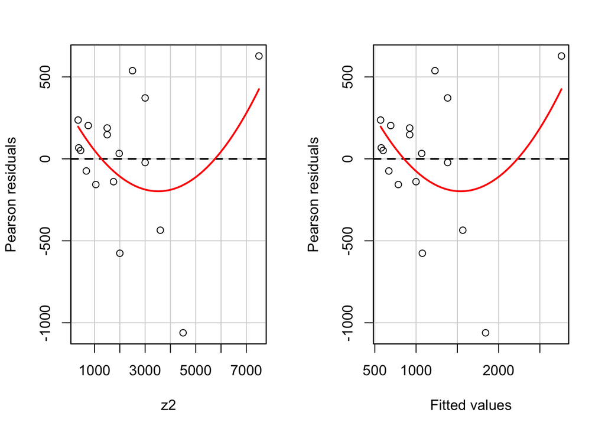

```
##            Test stat Pr(>|t|)
## z2             1.797    0.094
## Tukey test     1.797    0.072
```

```r
residualPlots(y1fit)
```

3. prediction interval for the mean function at a new observation z<sub>2</sub>=1200

```r
print(y1fitpred<-predict(y1fit, newdata = data.frame(z2=1200), interval = "predict"))
```

```
##        fit       lwr      upr
## 1 830.6676 -103.8228 1765.158
```

2. I used ANOVA to select variable and found that only z<sub>1</sub> and z<sub>2</sub> has significant effect.

```r
y2aov=aov(y2 ~z1+z2+z3+z4+z5, data = ami)
summary(y2aov)
```

```
##             Df  Sum Sq Mean Sq F value   Pr(>F)
## z1           1  532382  532382   6.225   0.0298 *
## z2           1 5457338 5457338  63.814 6.62e-06 ***
## z3           1  227012  227012   2.655   0.1315
## z4           1  320151  320151   3.744   0.0791 .
## z5           1  132786  132786   1.553   0.2386
## Residuals   11  940709   85519
## ---
## Signif. codes:  0 '***' 0.001 '**' 0.01 '*' 0.05 '.' 0.1 ' ' 1
```

(ii)Look at the Residuals

```r
y2fit=lm(y2~z1+z2,data=ami)
summary(y2fit)
```

```
##
## Call:
## lm(formula = y2 ~ z1 + z2, data = ami)
##
## Residuals:
##     Min      1Q  Median      3Q     Max
## -716.80 -135.83  -23.16  182.27  695.97
##
## Coefficients:
##               Estimate Std. Error t value Pr(>|t|)
## (Intercept) -241.34791  196.11640  -1.231  0.23874
## z11          606.30967  183.86521   3.298  0.00529 **
## z2             0.32425    0.04723   6.866 7.73e-06 ***
## ---
## Signif. codes:  0 '***' 0.001 '**' 0.01 '*' 0.05 '.' 0.1 ' ' 1
##
## Residual standard error: 340.2 on 14 degrees of freedom
## Multiple R-squared:  0.787,  Adjusted R-squared:  0.7566
## F-statistic: 25.87 on 2 and 14 DF,  p-value: 1.986e-05
```

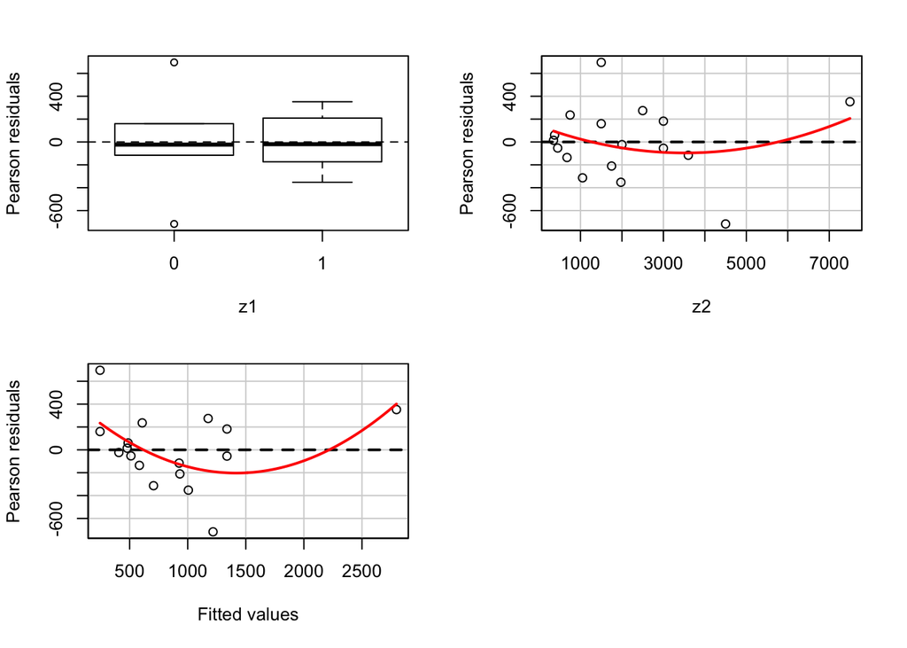

```
##            Test stat Pr(>|t|)
## z1                NA       NA
## z2             1.117    0.284
## Tukey test     2.518    0.012
```

```r
residualPlots(y2fit)
```

3. prediction interval for the mean function at a new observation z<sub>1</sub>=1,z<sub>2</sub>=1200

```r
print(y2fitpred<-predict(y2fit, newdata = data.frame(z1=as.factor(1),z2=1200), interval = "predict"))
```

```
##        fit       lwr      upr
## 1 754.0677 -9.234071 1517.369
```

3. (i)I used MANOVA to select variable and found that only z<sub>1</sub> and z<sub>2</sub> has significant effect.

```r
y1y2fit = lm(cbind(y1, y2) ~ ., data = ami)
Manova(y1y2fit)
```

```
##
## Type II MANOVA Tests: Pillai test statistic
##    Df test stat approx F num Df den Df   Pr(>F)
## z1  1   0.65521   9.5015      2     10 0.004873 **
## z2  1   0.69097  11.1795      2     10 0.002819 **
## z3  1   0.34649   2.6509      2     10 0.119200
## z4  1   0.32381   2.3944      2     10 0.141361
## z5  1   0.29184   2.0606      2     10 0.178092
## ---
## Signif. codes:  0 '***' 0.001 '**' 0.01 '*' 0.05 '.' 0.1 ' ' 1
```

After we remove variables other than z<sub>1</sub> and z<sub>2</sub>, we apply MANOVA again.

```r
fit_updated = lm(cbind(y1, y2) ~ z1+z2, data = ami)
Manova(fit_updated)
```

```
##
## Type II MANOVA Tests: Pillai test statistic
##    Df test stat approx F num Df den Df    Pr(>F)
## z1  1   0.45366   5.3974      2     13   0.01966 *
## z2  1   0.77420  22.2866      2     13 6.298e-05 ***
## ---
## Signif. codes:  0 '***' 0.001 '**' 0.01 '*' 0.05 '.' 0.1 ' ' 1
```

(ii)Look at the residuals

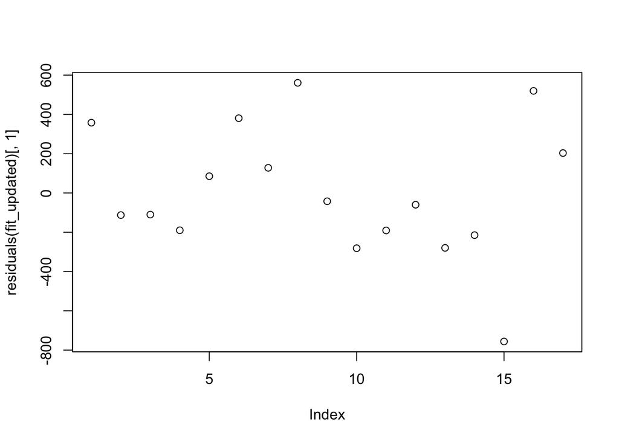

```r
plot(residuals(fit_updated)[,1])
```

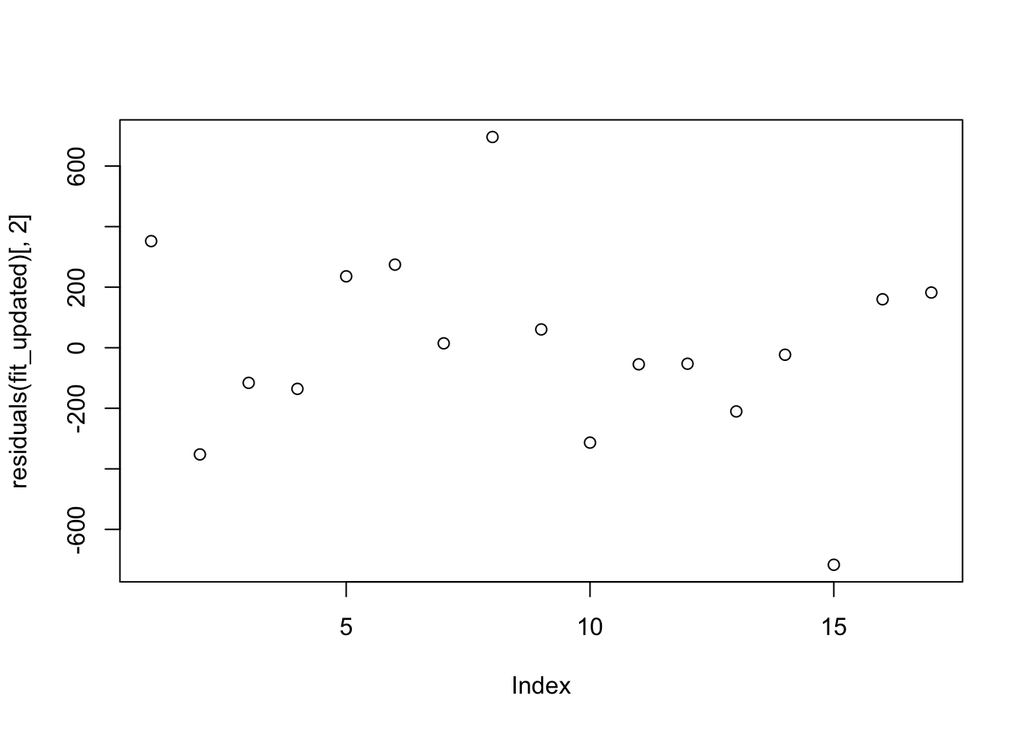

```r
plot(residuals(fit_updated)[,2])
```

(iii)

```r
z0<-data.frame(1,as.factor(1), 1200)
Z = cbind(1, ami$z1, ami$z2)
gram_inv = solve(t(Z) %*% Z)
predvals = predict(fit_updated, newdata = data.frame(z1=z0[1,2], z2 = z0[1,3]))
```

draw the prediction ellipse

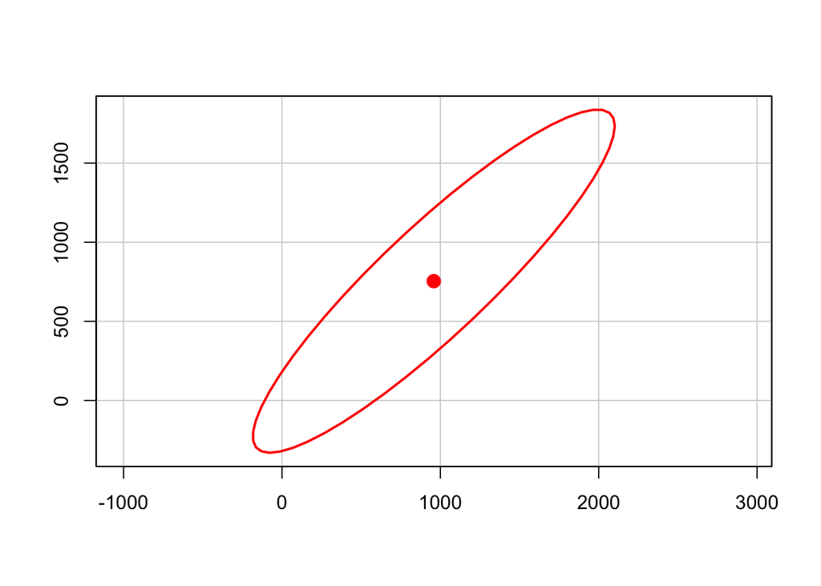

```r
z0<-c(1,1,1200)
n=nrow(ami)
m=2
r=2
Sigma_hat = t(fit_updated$residuals) %*% fit_updated$residuals/n
alpha = 0.05
radius_pred = drop(sqrt((1+ t(z0) %*% gram_inv %*% z0) *m * (n - r - 1)/(n - r- m) *qf(1-alpha, df1=m, df2=n-r-m)))
ellipse(center=as.vector(predvals), shape=n/(n-r-1)*Sigma_hat,radius=radius_pred, add=FALSE,  asp = 1)
```

Compare three Parts, we can see

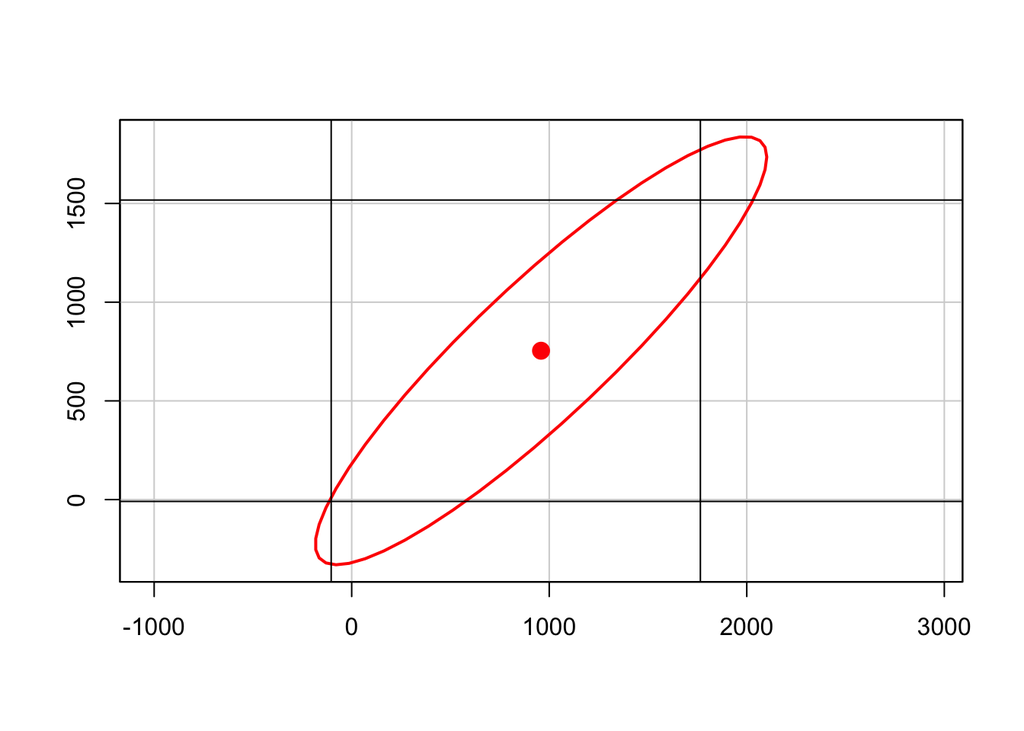

```r
ellipse(center=as.vector(predvals), shape=n/(n-r-1)*Sigma_hat,radius=radius_pred, add=FALSE,  asp = 1)
abline(h=y2fitpred[2])
abline(h=y2fitpred[3])
abline(v=y1fitpred[2])
abline(v=y1fitpred[3])
```

The ellipse for y1, y2 in Part 3 is larger than interval for y1 in Part 1 and interval for y2 in Part 2 7.26 (p. 427) (a)Perform a regression analysising using each of the response variables Y<sub>1</sub>,Y<sub>2</sub>,Y<sub>3</sub> and Y<sub>4</sub>.  
(i)Suggest and fit appropriate linear regression models  
(ii) Analyze the residuals.  
(iii)Construct a 95%prediction interval  
(b)Perform a multivaraite multiple regression analysis using all four variables and four independent variables.  
(i)Suggest and fit appropriate linear regression models  
(ii) Analyze the residuals.  
(iii)Construct a 95%prediction interval  
Solution:  
(a)  
(i)First import the data

```r
URL="http://users.stat.umn.edu/~guxxx192/courses/wichern_data/t7-7.dat"
fiber<-read.table(URL,col.names=c(paste0("y", 1:4), paste0("z", 1:4)))
```

FOr each response variable y

```r
summary(aov(y1 ~z1+z2+z3+z4, data = fiber))
```

```
##             Df Sum Sq Mean Sq F value   Pr(>F)
## z1           1 212.54  212.54  94.715 1.01e-13 ***
## z2           1  61.98   61.98  27.619 2.29e-06 ***
## z3           1   0.89    0.89   0.398    0.531
## z4           1 103.16  103.16  45.972 7.39e-09 ***
## Residuals   57 127.91    2.24
## ---
## Signif. codes:  0 '***' 0.001 '**' 0.01 '*' 0.05 '.' 0.1 ' ' 1
```

```r
summary(aov(y2 ~z1+z2+z3+z4, data = fiber))
```

```
##             Df Sum Sq Mean Sq F value   Pr(>F)
## z1           1  9.031   9.031   76.63 3.91e-12 ***
## z2           1  2.600   2.600   22.06 1.71e-05 ***
## z3           1  1.182   1.182   10.03  0.00248 **
## z4           1 11.785  11.785  100.00 3.76e-14 ***
## Residuals   57  6.717   0.118
## ---
## Signif. codes:  0 '***' 0.001 '**' 0.01 '*' 0.05 '.' 0.1 ' ' 1
```

```r
summary(aov(y3 ~z1+z2+z3+z4, data = fiber))
```

```
##             Df Sum Sq Mean Sq F value   Pr(>F)
## z1           1  60.49   60.49 144.409  < 2e-16 ***
## z2           1  15.89   15.89  37.939 7.87e-08 ***
## z3           1   0.39    0.39   0.941    0.336
## z4           1  29.89   29.89  71.371 1.24e-11 ***
## Residuals   57  23.88    0.42
## ---
## Signif. codes:  0 '***' 0.001 '**' 0.01 '*' 0.05 '.' 0.1 ' ' 1
```

```r
summary(aov(y4 ~z1+z2+z3+z4, data = fiber))
```

```
##             Df Sum Sq Mean Sq F value   Pr(>F)
## z1           1 14.618  14.618 120.139 1.17e-15 ***
## z2           1  3.992   3.992  32.804 4.00e-07 ***
## z3           1  0.002   0.002   0.013    0.911
## z4           1  3.750   3.750  30.817 7.71e-07 ***
## Residuals   57  6.936   0.122
## ---
## Signif. codes:  0 '***' 0.001 '**' 0.01 '*' 0.05 '.' 0.1 ' ' 1
```

(ii)Look at the Residuals

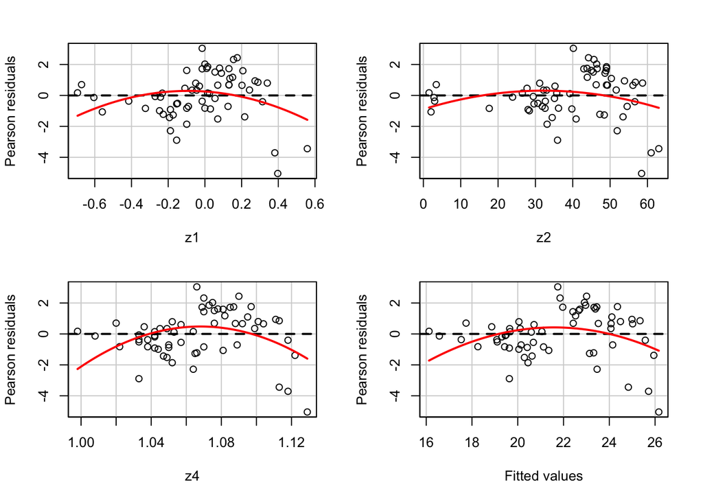

```
##            Test stat Pr(>|t|)
## z1            -2.487    0.016
## z2            -2.112    0.039
## z4            -3.216    0.002
## Tukey test    -2.531    0.011
```

```r
residualPlots(lm(y1~z1+z2+z4,data=fiber))
```

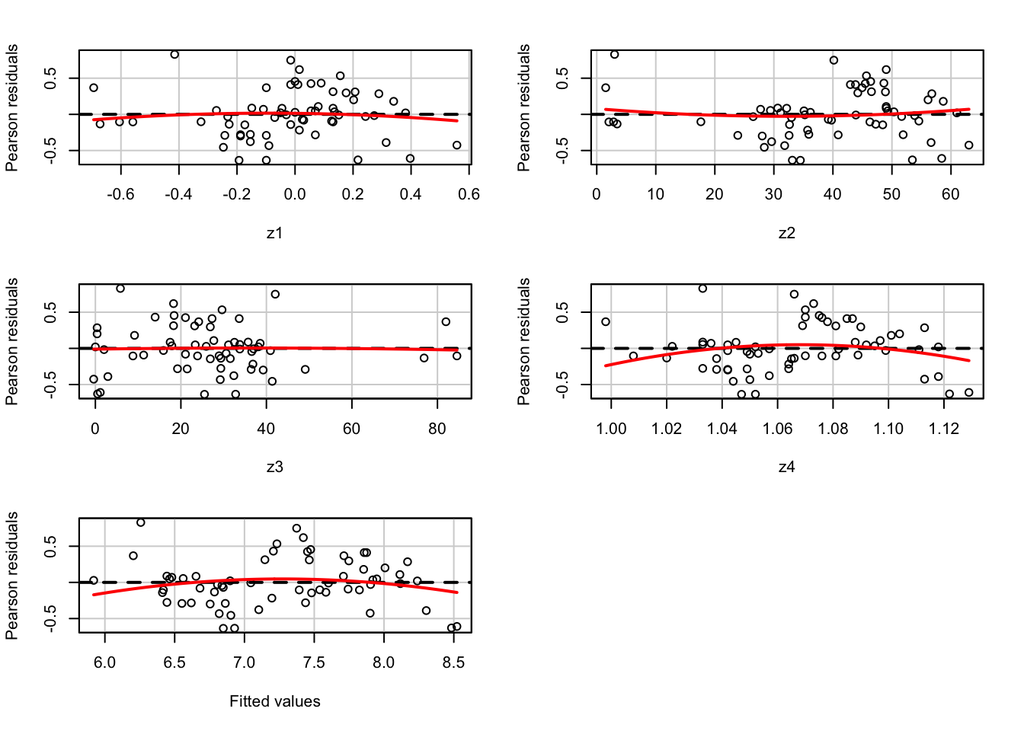

```
##            Test stat Pr(>|t|)
## z1            -0.635    0.528
## z2             0.824    0.413
## z3            -0.163    0.871
## z4            -1.495    0.141
## Tukey test    -1.174    0.240
```

```r
residualPlots(lm(y2~z1+z2+z3+z4,data=fiber))
```

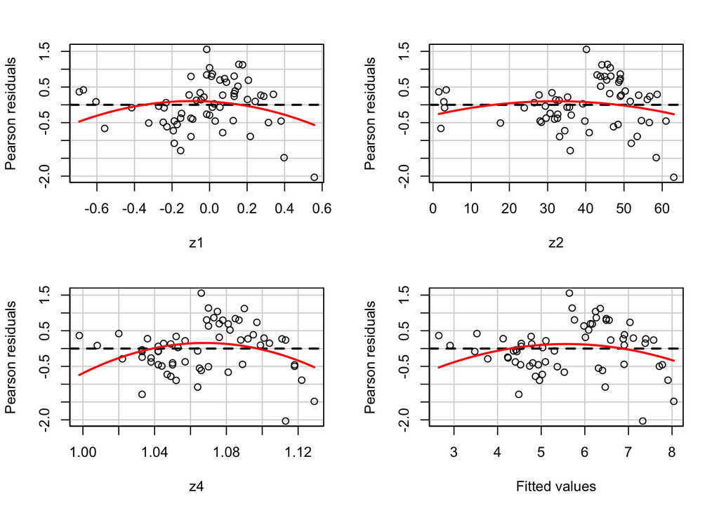

```
##            Test stat Pr(>|t|)
## z1            -1.981    0.052
## z2            -1.542    0.129
## z4            -2.290    0.026
## Tukey test    -1.701    0.089
```

```r
residualPlots(lm(y3~z1+z2+z4,data=fiber))
```

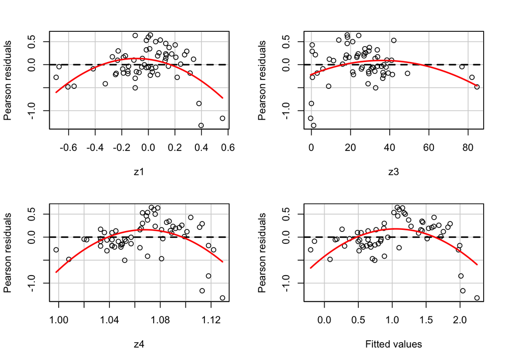

```
##            Test stat Pr(>|t|)
## z1            -5.017    0.000
## z3            -3.042    0.004
## z4            -4.673    0.000
## Tukey test    -4.853    0.000
```

```r
residualPlots(lm(y4~z1+z3+z4,data=fiber))
```

```r
y3fit<-lm(y3~z1+z2+z4,data=fiber)
print(y3pred<-predict(y3fit, newdata = data.frame(z1=0.33,z2=1200,z4=1.01), interval = "predict"))
```

```
##        fit      lwr      upr
## 1 56.97967 22.64851 91.31082
```

2. (i)I apply MANOVA

```r
y1to4fit = lm(cbind(y1,y2,y3,y4) ~ ., data = fiber)
Manova(y1to4fit)
```

```
##
## Type II MANOVA Tests: Pillai test statistic
##    Df test stat approx F num Df den Df    Pr(>F)
## z1  1   0.15658   2.5063      4     54   0.05266 .
## z2  1   0.40420   9.1585      4     54 1.009e-05 ***
## z3  1   0.21143   3.6196      4     54   0.01100 *
## z4  1   0.69523  30.7959      4     54 2.308e-13 ***
## ---
## Signif. codes:  0 '***' 0.001 '**' 0.01 '*' 0.05 '.' 0.1 ' ' 1
```

Choose z<sub>2</sub>,z<sub>3</sub> and z<sub>4</sub> to update the model

```r
y1to4fit_updated = lm(cbind(y1,y2,y3,y4) ~ z2+z3+z4, data = fiber)
print(beta_hat<-coefficients(y1to4fit_updated))
```

```
##                       y1            y2           y3           y4
## (Intercept) -70.11680766 -22.452187336 -43.80405567 -17.00202079
## z2            0.05930052  -0.005402808   0.02879950   0.02241805
## z3            0.05552102   0.010677278   0.02821556   0.01203017
## z4           82.53024673  27.788003873  44.58604066  15.77121827
```

```r
epls=residuals(y1to4fit_updated)
n=nrow(epls)
r=3
print(sigma_hat<-(t(epls)%*%epls)/(n-r-1))
```

```
##           y1         y2        y3         y4
## y1 2.3080365 0.43013471 0.9470760 0.52022157
## y2 0.4301347 0.13063506 0.2080697 0.09465806
## y3 0.9470760 0.20806968 0.4349349 0.21471978
## y4 0.5202216 0.09465806 0.2147198 0.12277153
```

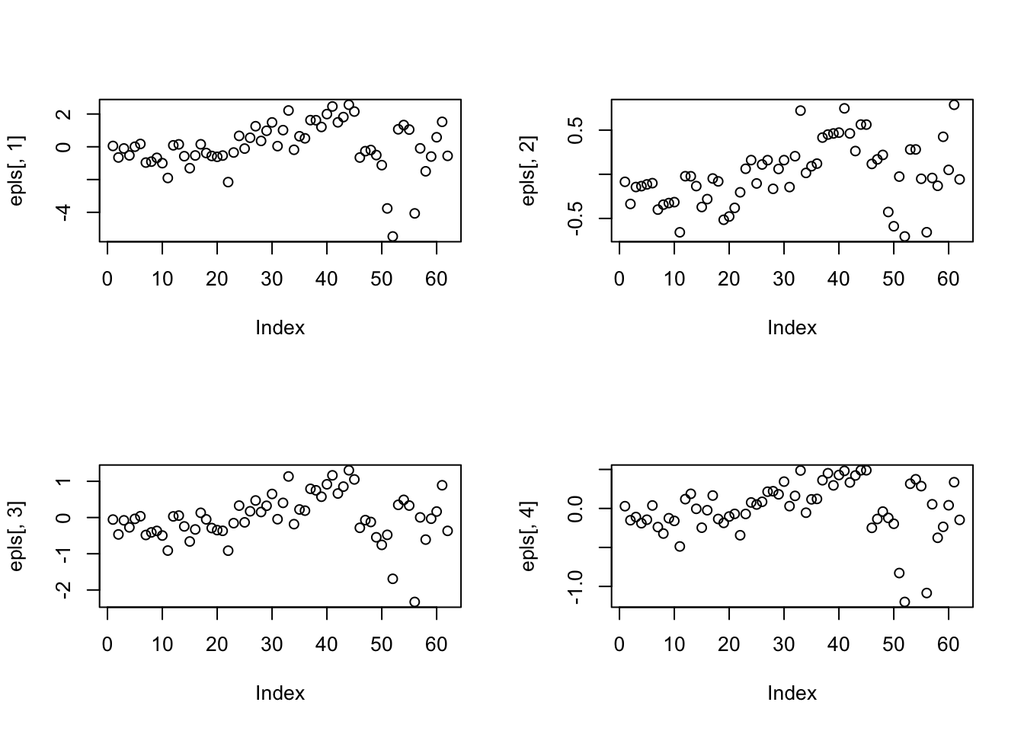

```r
par(mfrow = c(2,2))
plot(epls[,1])
plot(epls[,2])
plot(epls[,3])
plot(epls[,4])
```

```r
z0<-c(1,45.5,20.375,1.01)
Z = cbind(1, fiber$z2, fiber$z3,fiber$z4)
predvals = predict(y1to4fit_updated, newdata = data.frame(z2=z0[2], z3= z0[3], z4=z0[4]))
gram_inv = solve(t(Z) %*% Z)
radius_pred = drop(sqrt((1+ t(z0)%*% gram_inv %*% z0 )*m* (n - r - 1)/(n - r- m) *qf(1-alpha, df1=m, df2=n-r-m)))
```

calculate the prediction interval

```r
print(y1low<-predvals[1]-radius_pred*sqrt(sigma_hat[1,1]*n/(n-r-1)) )
```

```
## [1] 12.46623
```

```r
print(y1upp<-predvals[1]+radius_pred*sqrt(sigma_hat[1,1]*n/(n-r-1)) )
```

```
## [1] 21.67008
```

```r
print(y2low<-predvals[2]-radius_pred*sqrt(sigma_hat[2,2]*n/(n-r-1)) )
```

```
## [1] 4.490585
```

```r
print(y2upp<-predvals[2]+radius_pred*sqrt(sigma_hat[2,2]*n/(n-r-1)) )
```

```
## [1] 6.680252
```

```r
print(y3low<-predvals[3]-radius_pred*sqrt(sigma_hat[3,3]*n/(n-r-1)) )
```

```
## [1] 1.115414
```

```r
print(y3upp<-predvals[3]+radius_pred*sqrt(sigma_hat[3,3]*n/(n-r-1)) )
```

```
## [1] 5.110815
```

```r
print(y4low<-predvals[4]-radius_pred*sqrt(sigma_hat[4,4]*n/(n-r-1)) )
```

```
## [1] -0.8693251
```

```r
print(y4upp<-predvals[4]+radius_pred*sqrt(sigma_hat[4,4]*n/(n-r-1)) )
```

```
## [1] 1.253416
```